# HW1

## QUESTION 3

**The Palmer Penguins data set is another fun R data set. It contains data on 3 types of penguins that can be found on the Palmer archipelago in Antarctica: chinstrap, gentoo, and adelie. These data were collected from 2007 - 2009 by Dr. Kristen Gorman with the Palmer Station Long Term Ecological Research Program, part of the US Long Term Ecological Research Network.**

### Part 1

**Make a bar chart of the number of penguins per island, and note the species of penguins on each one. What patterns do you observe?**

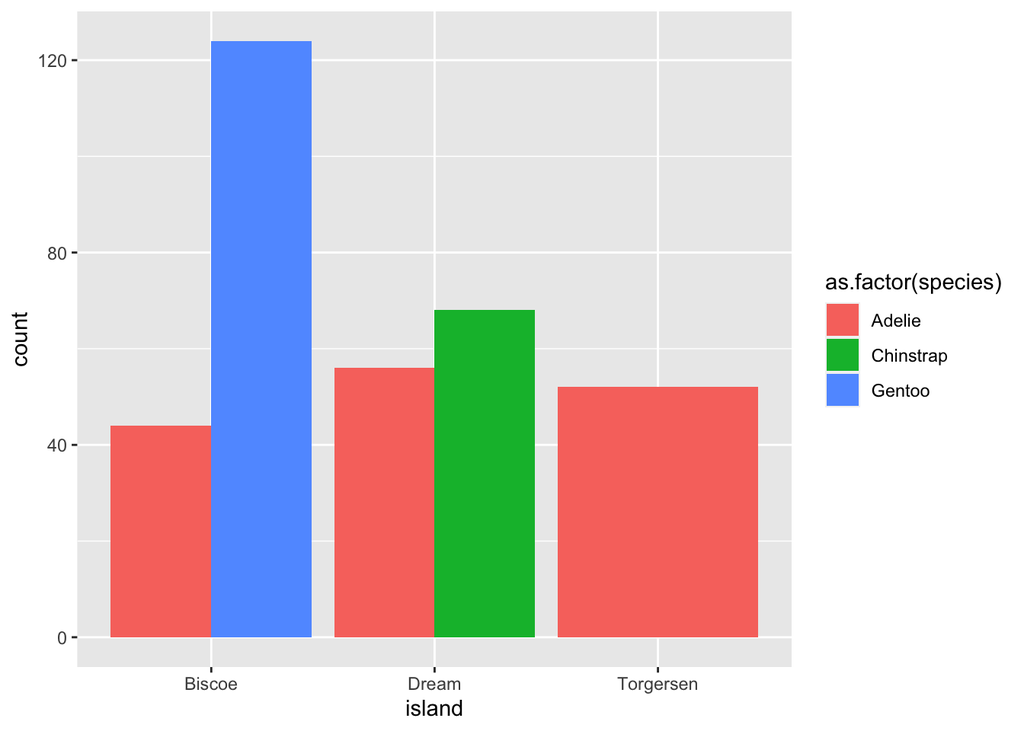

```r
ggplot(data=penguins) +
  geom_bar(aes(x=island, fill = as.factor(species)), position = 'dodge')
```

Firstly, the island with most penguins is Biscoe, followed by Dream, and lastly Torgersen. Interestingly, the Adelie species is present on each island, yet, on Biscoe and Dream, Adelie penguins are the second most common species. The data shows that the Gentoo species is only present on Biscoe, while Chinstrap is only present on Dream island.

### Part 2

**Examine the relationship between flipper length and body mass, by species.**

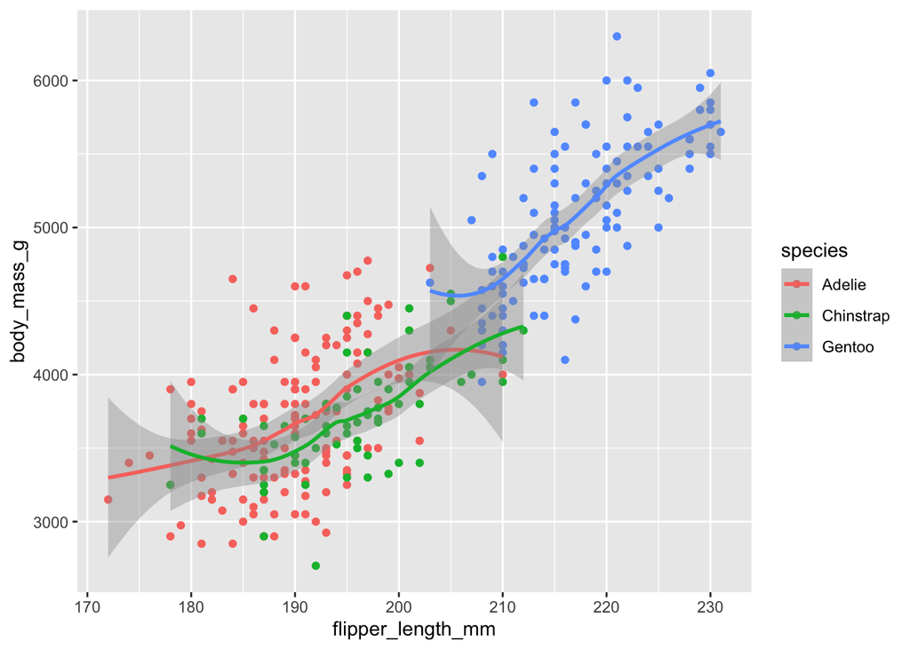

```r
ggplot(data=penguins, aes(x=flipper_length_mm, y=body_mass_g, color = species)) +
  geom_point() +
  geom_smooth()
```

Overall, for all three species, I find a relatively positive trend between flipper length and body mass, which makes sense because you would expect a larger and heavier penguin to have a longer flipper. Also, the Gentoo penguins seem to be the biggest species between the three, given their body mass and flipper length.

### Part 3

**What do you find once you separate out the data by sex?**

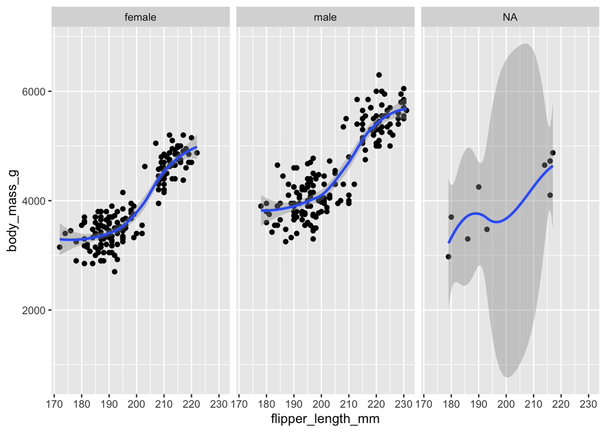

```r
ggplot(data=penguins, aes(x=flipper_length_mm, y=body_mass_g)) +
  geom_point() +
  geom_smooth()+
  facet_wrap(~ sex)
```

I find that for both male and female penguins, there is also a relatively positive trend between flipper length and body mass, yet, we can see the data points being slightly higher in both body mass and flipper length for male penguins. Moreover, there are some penguins whose sex were not identifiable, thus the NA values.

### Part 4

**Examine the relationship between bill length and depth. First, pool across all species, and give a linear summary of the effect. What do you observe? What happens once you split by species?**

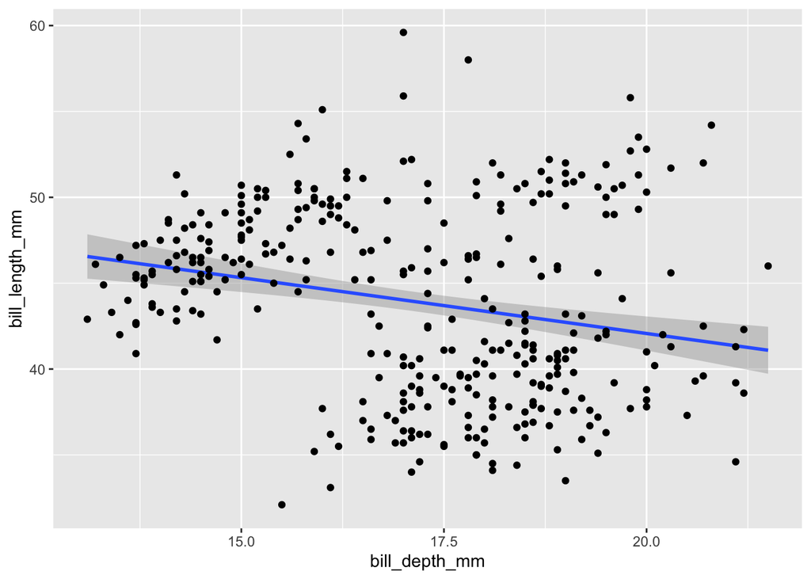

```r
ggplot(data=penguins) +
  geom_smooth(method="lm", aes(x=bill_depth_mm, y=bill_length_mm)) +
  geom_point(aes(x=bill_depth_mm, y=bill_length_mm))
```

The plot shows that bill depth and length have a negative linear relationship, in other words, the deeper the bill, the shorter it is.

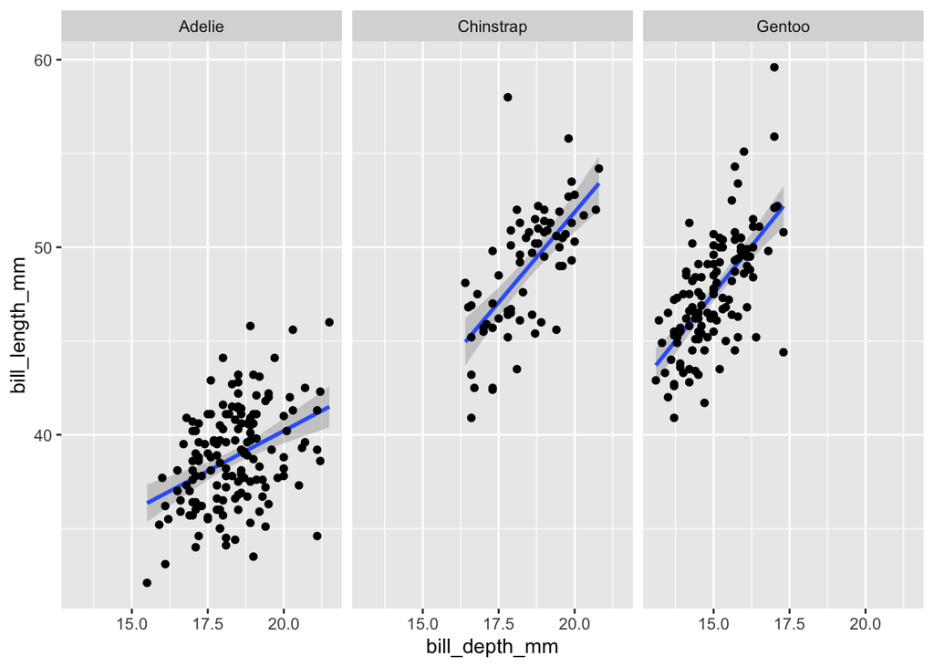

```r
ggplot(data=penguins) +
  geom_smooth(method="lm", aes(x=bill_depth_mm, y=bill_length_mm)) +
  geom_point(aes(x=bill_depth_mm, y=bill_length_mm)) +
  facet_wrap(~ species)
```

However, when we separate the data by species, we can see a positive relationship between bill length and depth in all species. This could be an example of Simpson’s paradox.